# Homework 1 - Dario Placencio

Consider data set PropertyFund.txt. We are interested in the prediction of variable Freq.

```r
read.table("PropertyFund.txt", header = TRUE, sep = " ", dec = ".", stringsAsFactors = FALSE) -> PropertyFund
```

##### 1. Show the frequency table of variable Freq. Comment on its characteristics.

```r
# Define Variable
table(PropertyFund$Freq) -> freq_tab
```

```r
# Mean of Freq
mean(PropertyFund$Freq) -> mean_freq
mean_freq
```

```
## [1] 0.6262042
```

```r
# Median of Freq
median(PropertyFund$Freq) -> median_freq
median_freq
```

```
## [1] 0
```

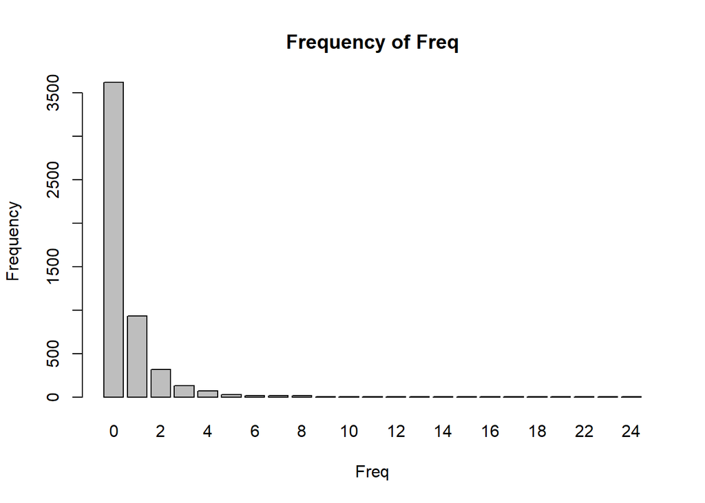

The mean is ~ 0.63 for number of claims and the median is 0. The frequency table shows that the most frequent value is 0, which is also the median. The frequency table shows that the values 0 and 1 are the most frequent values.

##### 2. Split data into two parts, using observations from 2006-2008 as training and the rest as test data. Fit a simple linear regression of Freq on Coverage using training data. Report results.Comment on the predictive power of Coverage. Provide justifications.

```r
PropertyFund$EntityType <- relevel(as.factor(PropertyFund$EntityType),ref="Misc")
```

```r
# Training data
PropertyFund[PropertyFund$Year <= 2008, ] -> PropertyFund_train
```

```r
# Test data
PropertyFund[PropertyFund$Year > 2008, ] -> PropertyFund_test
```

```r
# Fit a simple linear regression of Freq on Coverage using training data
lm(Freq ~ Coverage, data = PropertyFund_train) -> model1
```

```r
# Report results
summary(model1)
```

```
##
## Call:
## lm(formula = Freq ~ Coverage, data = PropertyFund_train)
##
## Residuals:
##     Min      1Q  Median      3Q     Max
## -8.4764 -0.4939 -0.4137  0.2606 22.6400
##
## Coefficients:
##              Estimate Std. Error t value Pr(>|t|)
## (Intercept) 0.4020787  0.0294972   13.63   <2e-16 ***
## Coverage    0.0060801  0.0003529   17.23   <2e-16 ***
## ---
## Signif. codes:  0 '***' 0.001 '**' 0.01 '*' 0.05 '.' 0.1 ' ' 1
##
## Residual standard error: 1.504 on 3112 degrees of freedom
## Multiple R-squared:  0.08708,    Adjusted R-squared:  0.08679
## F-statistic: 296.9 on 1 and 3112 DF,  p-value: < 2.2e-16
```

The Multiple R-squared value is 0.08708, which means that the model explains only ~ 8% of the variability of frequency based on coverage. The p-value is < 2.2e-16, which means that the model is statistically significant. The coefficient of Coverage is 0.0060801, which means that the model is not very useful for prediction, given the bigger magnitude on the intercept.

##### 3. Write out the model (including model assumptions) that you fit in Question 2. Indicate the parameters of the model and their estimates.

Freq = 0.0060801 * Coverage + 0.4020787

##### 4. Suppose an analyst uses the fitted model in Question 2 to predict the response variable. Will the analyst obtain a negative predictive value for the number of claims? Explain your answer.

The analyst will not get negative values because the coefficients are positive.

##### 5. Refit the model in Question 2 by including EntityType in addition to Coverage. Report the results. Comment on the predictive power of EntityType. Provide justifications.

```r
# Refit the model by including EntityType in addition to Coverage
lm(Freq ~ Coverage + EntityType, data = PropertyFund_train) -> model2
```

```r
# Report the results
summary(model2)
```

```
##
## Call:
## lm(formula = Freq ~ Coverage + EntityType, data = PropertyFund_train)
##
## Residuals:
##     Min      1Q  Median      3Q     Max
## -6.8779 -0.3946 -0.2825 -0.0339 22.0692
##
## Coefficients:
##                    Estimate Std. Error t value Pr(>|t|)
## (Intercept)       0.0328047  0.0789941   0.415  0.67797
## Coverage          0.0046013  0.0003572  12.883  < 2e-16 ***
## EntityTypeCity    1.1730814  0.1040364  11.276  < 2e-16 ***
## EntityTypeCounty  1.7833736  0.1333456  13.374  < 2e-16 ***
## EntityTypeSchool  0.2296004  0.0922500   2.489  0.01287 *
## EntityTypeTown    0.0544307  0.1006230   0.541  0.58859
## EntityTypeVillage 0.3021399  0.0949174   3.183  0.00147 **
## ---
## Signif. codes:  0 '***' 0.001 '**' 0.01 '*' 0.05 '.' 0.1 ' ' 1
##
## Residual standard error: 1.426 on 3107 degrees of freedom
## Multiple R-squared:  0.1811, Adjusted R-squared:  0.1795
## F-statistic: 114.5 on 6 and 3107 DF,  p-value: < 2.2e-16
```

The Multiple R-squared value is 0.1811, which means that the new model explains 18% of the variability of frequency, with an improvement of around 10% given the inclusion of the entity variable. The p-value is < 2.2e-16, which means that the model is statistically significant. The coefficients of EntityType compared to Coverage are considerable bigger, which reflect on the bigger influence of these variables on frequency.

##### 6. Use the fitted model in Question 5 to make predictions of Freq in the test data. Calculate the linear correlation coefficient between predicted values and observed values. Comment on the magnitude of the correlation.

```r
# Use the fitted model in Question 5 to make predictions of Freq in the test data
predict(model2, PropertyFund_test) -> predicted_freq
```

```r
# Calculate the linear correlation coefficient between predicted values and observed values
cor(predicted_freq, PropertyFund_test$Freq) -> corr
```

```r
corr
```

```
## [1] 0.4743426
```

The correlation is 0.4743426, is positive so the predicted and observed values move in the same direction. This is a relatively strong correlation close to the 0.5 mark.